# Phi4-mini GFC-30 TIRT Analysis

Persona recovery, trait structure, and neutral model placement

2026-04-13

# Introduction

This report analyzes Phi4-mini’s responses to the Okada et al. (2026) GFC-30 (Graded Forced-Choice Big Five) instrument, administered under 400 synthetic personas with known ground-truth trait profiles. Phi4-mini is a smaller reasoning-capable model from Microsoft; its higher response entropy (mean ~1.58 nats vs Gemma3’s ~0.67) suggests it spreads probability more evenly across the 7-point GFC scale, which could yield better TIRT identification.

We fit a Thurstonian IRT (TIRT) model using `thurstonianIRT` (Stan backend, cumulative family, **4 chains** x 1000 iterations) — an upgrade from the Gemma3 2-chain run that showed signs of insufficient posterior mixing.

The analysis mirrors the Gemma3 report: ground-truth recovery, trait correlation structure, response distributions, and neutral model placement under two prompt conditions.

# 1. TIRT Fit Summary

```r
fit <- readRDS("phi4_gfc30_synthetic_tirt_fit.rds")

# Load instrument metadata + build blocks
inst <- fromJSON("../instruments/okada_gfc30.json")
pairs <- inst$pairs

block_df <- tibble(
  block = rep(seq_len(nrow(pairs)), each = 2),
  item = character(nrow(pairs) * 2),
  trait = character(nrow(pairs) * 2),
  sign = numeric(nrow(pairs) * 2)
)
for (i in seq_len(nrow(pairs))) {
  left_name <- paste0(pairs$left$trait[i],
                       ifelse(pairs$left$keying[i] == "+", "p", "n"), i)
  right_name <- paste0(pairs$right$trait[i],
                        ifelse(pairs$right$keying[i] == "+", "p", "n"), i)
  idx <- (i - 1) * 2
  block_df$item[idx + 1] <- left_name
  block_df$trait[idx + 1] <- pairs$left$trait[i]
  block_df$sign[idx + 1] <- ifelse(pairs$left$keying[i] == "+", 1, -1)
  block_df$item[idx + 2] <- right_name
  block_df$trait[idx + 2] <- pairs$right$trait[i]
  block_df$sign[idx + 2] <- ifelse(pairs$right$keying[i] == "+", 1, -1)
}
blocks <- set_blocks_from_df(block_df)

# Load ground truth
personas_json <- fromJSON("../instruments/synthetic_personas.json")
ground_truth <- tibble(
  persona_id = personas_json$personas$persona_id,
  A_true = personas_json$personas$z_scores$A,
  C_true = personas_json$personas$z_scores$C,
  E_true = personas_json$personas$z_scores$E,
  N_true = personas_json$personas$z_scores$N,
  O_true = personas_json$personas$z_scores$O
)

# Wide CSV for persona ID ordering
wide <- read_csv("phi4-mini_gfc30_synthetic_wide.csv", show_col_types = FALSE)
complete_mask <- complete.cases(wide[, -1])
persona_ids <- wide$persona_id[complete_mask]
n_complete <- sum(complete_mask)

cat(sprintf("Complete respondents: %d / %d\n", n_complete, nrow(wide)))
```

```
## Complete respondents: 400 / 400
```

```r
scores_long <- as_tibble(predict(fit))

scores_wide <- scores_long %>%
  pivot_wider(names_from = trait,
              values_from = c(estimate, se, lower_ci, upper_ci),
              names_glue = "{trait}_{.value}") %>%
  mutate(persona_id = persona_ids) %>%
  left_join(ground_truth, by = "persona_id")
```

# 2. Ground-Truth Recovery

We compare two scoring approaches against the known trait z-scores used to generate each persona:

## Recovery Correlations

```r
raw <- fromJSON("phi4-mini_gfc30_synthetic.json", flatten = TRUE)
all_results <- as_tibble(raw$results)

trait_evidence <- all_results %>%
  filter(!is.na(response_argmax)) %>%
  mutate(
    resp_val = coalesce(as.numeric(response_ev), as.numeric(response_argmax)),
    pref = resp_val - 4,
    right_endorsement = pref * ifelse(right_keying == "+", 1, -1),
    left_endorsement = -pref * ifelse(left_keying == "+", 1, -1)
  )

simple_scores <- bind_rows(
  trait_evidence %>% select(persona_id, trait = right_trait,
                            endorsement = right_endorsement),
  trait_evidence %>% select(persona_id, trait = left_trait,
                            endorsement = left_endorsement)
) %>%
  group_by(persona_id, trait) %>%
  summarise(score = mean(endorsement, na.rm = TRUE), .groups = "drop") %>%
  pivot_wider(names_from = trait, values_from = score) %>%
  left_join(ground_truth, by = "persona_id")

recovery <- tibble(trait = traits) %>%
  rowwise() %>%
  mutate(
    tirt_r = cor(scores_wide[[paste0(trait, "_estimate")]],
                 scores_wide[[paste0(trait, "_true")]],
                 use = "complete.obs"),
    simple_r = cor(simple_scores[[trait]],
                   simple_scores[[paste0(trait, "_true")]],
                   use = "complete.obs"),
    trait_name = trait_labels[trait]
  ) %>%
  ungroup()

knitr::kable(recovery %>% select(Trait = trait_name, TIRT = tirt_r,
                                  Simple = simple_r),
             digits = 3, caption = "Ground-truth recovery (Pearson r)")
```

Ground-truth recovery (Pearson r)

| Trait | TIRT | Simple |
| --- | --- | --- |
| Agreeableness | -0.386 | 0.275 |
| Conscientiousness | -0.202 | 0.086 |
| Extraversion | -0.387 | 0.487 |
| Neuroticism | -0.340 | 0.086 |
| Openness | -0.577 | 0.508 |

## Scatterplots: TIRT Scores vs Ground Truth

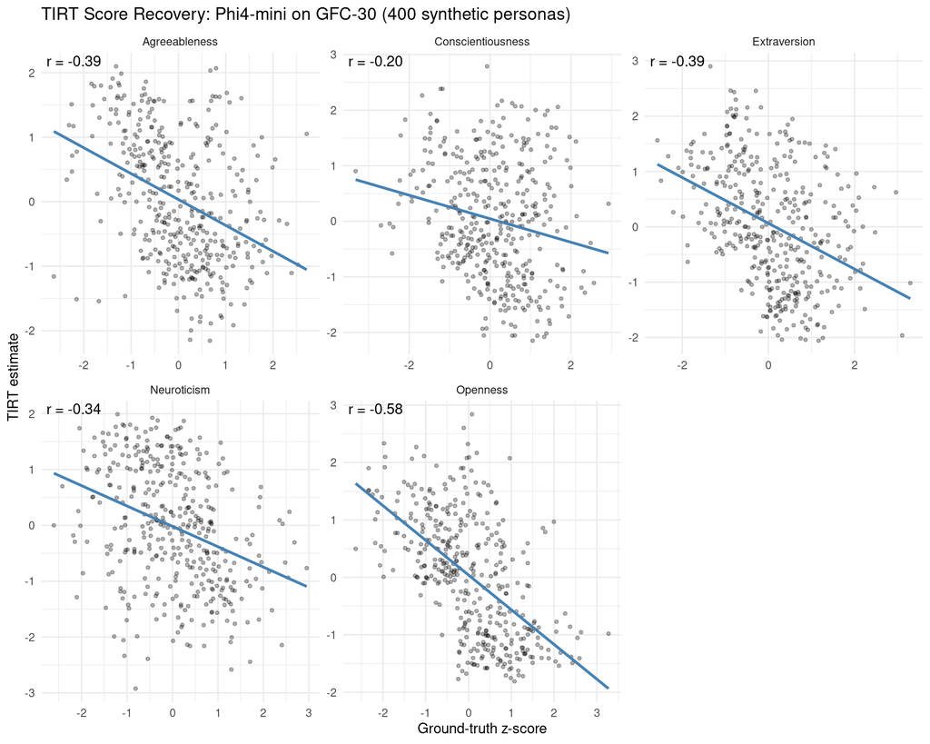

```r
scatter_data <- scores_wide %>%
  pivot_longer(cols = matches("^[ACENO]_(estimate|true)$"),
               names_to = c("trait", ".value"),
               names_pattern = "^(.)_(.+)$")

ggplot(scatter_data, aes(x = true, y = estimate)) +
  geom_point(alpha = 0.3, size = 1) +
  geom_smooth(method = "lm", se = FALSE, color = "steelblue") +
  geom_text(data = recovery, aes(label = sprintf("r = %.2f", tirt_r),
                                  x = -Inf, y = Inf),
            hjust = -0.1, vjust = 1.3, size = 4, inherit.aes = FALSE) +
  facet_wrap(~ trait, scales = "free", labeller = labeller(
    trait = trait_labels)) +
  labs(x = "Ground-truth z-score", y = "TIRT estimate",
       title = "TIRT Score Recovery: Phi4-mini on GFC-30 (400 synthetic personas)") +
  theme_minimal()
```

## Simple Scoring Recovery

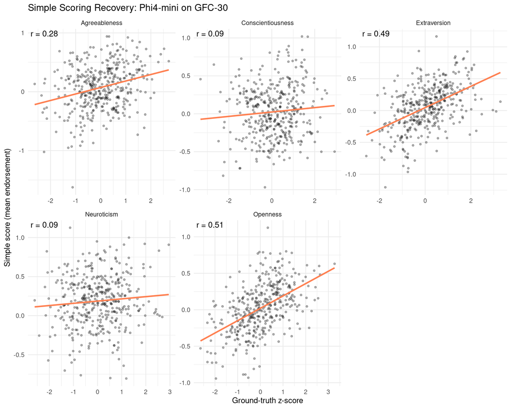

```r
simple_long <- simple_scores %>%
  pivot_longer(cols = all_of(traits), names_to = "trait",
               values_to = "simple_est") %>%
  left_join(
    ground_truth %>%
      pivot_longer(-persona_id, names_to = "trait", values_to = "true",
                   names_pattern = "(.)_true"),
    by = c("persona_id", "trait")
  )

ggplot(simple_long, aes(x = true, y = simple_est)) +
  geom_point(alpha = 0.3, size = 1) +
  geom_smooth(method = "lm", se = FALSE, color = "coral") +
  geom_text(data = recovery, aes(label = sprintf("r = %.2f", simple_r),
                                  x = -Inf, y = Inf),
            hjust = -0.1, vjust = 1.3, size = 4, inherit.aes = FALSE) +
  facet_wrap(~ trait, scales = "free", labeller = labeller(
    trait = trait_labels)) +
  labs(x = "Ground-truth z-score", y = "Simple score (mean endorsement)",
       title = "Simple Scoring Recovery: Phi4-mini on GFC-30") +
  theme_minimal()
```

## Cross-Model Comparison

How does Phi4-mini compare to Gemma3 12B on the same instrument and personas?

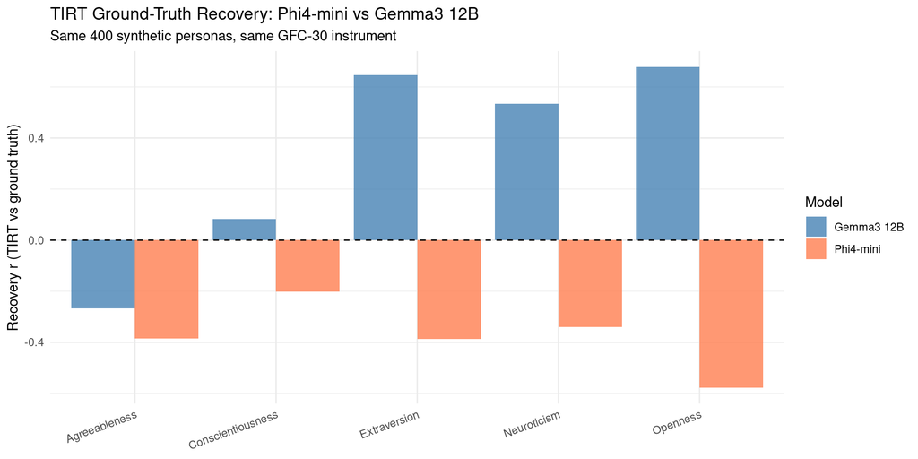

```r
# Load Gemma3 recovery from its saved fit
gemma3_fit <- readRDS("gemma3_gfc30_synthetic_tirt_fit.rds")
gemma3_scores <- as_tibble(predict(gemma3_fit))
gemma3_wide_csv <- read_csv("gemma3-12b_gfc30_synthetic_wide.csv",
                             show_col_types = FALSE)
gemma3_mask <- complete.cases(gemma3_wide_csv[, -1])
gemma3_ids <- gemma3_wide_csv$persona_id[gemma3_mask]

gemma3_scores_wide <- gemma3_scores %>%
  pivot_wider(names_from = trait,
              values_from = c(estimate, se, lower_ci, upper_ci),
              names_glue = "{trait}_{.value}") %>%
  mutate(persona_id = gemma3_ids) %>%
  left_join(ground_truth, by = "persona_id")

gemma3_recovery <- tibble(trait = traits) %>%
  rowwise() %>%
  mutate(
    r = cor(gemma3_scores_wide[[paste0(trait, "_estimate")]],
            gemma3_scores_wide[[paste0(trait, "_true")]],
            use = "complete.obs"),
    model = "Gemma3 12B"
  ) %>%
  ungroup()

phi4_recovery <- recovery %>%
  select(trait, r = tirt_r) %>%
  mutate(model = "Phi4-mini")

cross_model <- bind_rows(gemma3_recovery, phi4_recovery)

ggplot(cross_model, aes(x = trait, y = r, fill = model)) +
  geom_col(position = "dodge", alpha = 0.8) +
  geom_hline(yintercept = 0, linetype = "dashed") +
  scale_fill_manual(values = c("Gemma3 12B" = "steelblue",
                                "Phi4-mini" = "coral")) +
  scale_x_discrete(labels = trait_labels) +
  labs(x = NULL, y = "Recovery r (TIRT vs ground truth)",
       title = "TIRT Ground-Truth Recovery: Phi4-mini vs Gemma3 12B",
       subtitle = "Same 400 synthetic personas, same GFC-30 instrument",
       fill = "Model") +
  theme_minimal() +
  theme(axis.text.x = element_text(angle = 20, hjust = 1))
```

# 3. Estimated Trait Correlations

```r
tirt_cor <- scores_wide %>%
  select(all_of(paste0(traits, "_estimate"))) %>%
  cor(use = "complete.obs")
colnames(tirt_cor) <- traits
rownames(tirt_cor) <- traits

gt_cor <- ground_truth %>%
  select(all_of(paste0(traits, "_true"))) %>%
  cor()
colnames(gt_cor) <- traits
rownames(gt_cor) <- traits

simple_cor <- simple_scores %>%
  select(all_of(traits)) %>%
  cor(use = "complete.obs")
```

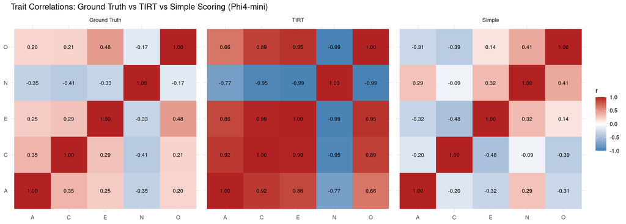

```r
make_cor_long <- function(mat, label) {
  as.data.frame(as.table(mat)) %>%
    rename(Var1 = 1, Var2 = 2, value = 3) %>%
    mutate(source = label)
}

cor_all <- bind_rows(
  make_cor_long(gt_cor, "Ground Truth"),
  make_cor_long(tirt_cor, "TIRT"),
  make_cor_long(simple_cor, "Simple")
) %>%
  mutate(source = factor(source, levels = c("Ground Truth", "TIRT", "Simple")))

ggplot(cor_all, aes(Var1, Var2, fill = value)) +
  geom_tile() +
  geom_text(aes(label = sprintf("%.2f", value)), size = 3) +
  scale_fill_gradient2(low = "steelblue", mid = "white", high = "firebrick",
                       midpoint = 0, limits = c(-1, 1)) +
  facet_wrap(~ source) +
  labs(title = "Trait Correlations: Ground Truth vs TIRT vs Simple Scoring (Phi4-mini)",
       x = NULL, y = NULL, fill = "r") +
  theme_minimal() +
  theme(axis.text.x = element_text(angle = 0))
```

With 4 chains (vs Gemma3’s 2), we expect better posterior exploration and potentially more realistic inter-trait correlations. If TIRT still produces implausibly high correlations, the issue is more likely data-driven (insufficient between-person variation in GFC responses) than sampling-driven.

# 4. Response Distribution

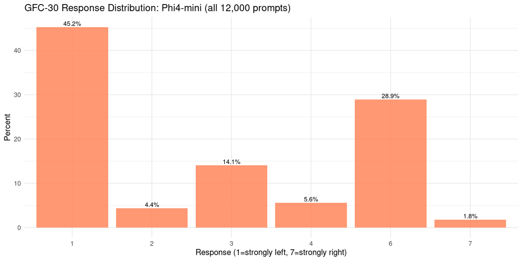

```r
all_results %>%
  filter(!is.na(response_argmax)) %>%
  mutate(response = as.integer(response_argmax)) %>%
  count(response) %>%
  mutate(pct = n / sum(n) * 100) %>%
  ggplot(aes(x = factor(response), y = pct)) +
  geom_col(fill = "coral", alpha = 0.8) +
  geom_text(aes(label = sprintf("%.1f%%", pct)), vjust = -0.3, size = 3) +
  labs(x = "Response (1=strongly left, 7=strongly right)",
       y = "Percent",
       title = "GFC-30 Response Distribution: Phi4-mini (all 12,000 prompts)") +
  theme_minimal()
```

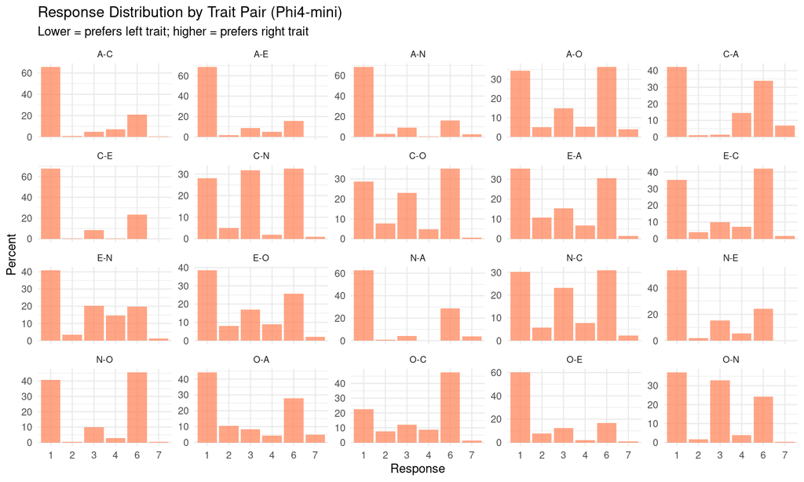

```r
all_results %>%
  filter(!is.na(response_argmax)) %>%
  mutate(response = as.integer(response_argmax)) %>%
  count(left_trait, right_trait, response) %>%
  group_by(left_trait, right_trait) %>%
  mutate(pct = n / sum(n) * 100) %>%
  ungroup() %>%
  mutate(pair = paste0(left_trait, "-", right_trait)) %>%
  ggplot(aes(x = factor(response), y = pct)) +
  geom_col(fill = "coral", alpha = 0.7) +
  facet_wrap(~ pair, scales = "free_y") +
  labs(x = "Response", y = "Percent",
       title = "Response Distribution by Trait Pair (Phi4-mini)",
       subtitle = "Lower = prefers left trait; higher = prefers right trait") +
  theme_minimal() +
  theme(strip.text = element_text(size = 8))
```

Phi4-mini’s higher entropy means we expect a flatter distribution compared to Gemma3’s peaked responses. More spread across the scale should provide richer signal for TIRT estimation.

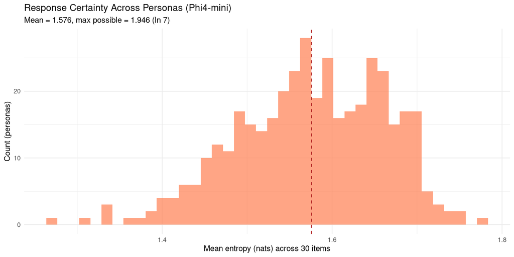

```r
persona_entropy <- all_results %>%
  filter(!is.na(response_entropy)) %>%
  group_by(persona_id) %>%
  summarise(mean_entropy = mean(response_entropy, na.rm = TRUE),
            mean_ev = mean(as.numeric(response_ev), na.rm = TRUE),
            .groups = "drop")

ggplot(persona_entropy, aes(x = mean_entropy)) +
  geom_histogram(bins = 40, fill = "coral", alpha = 0.7) +
  geom_vline(xintercept = mean(persona_entropy$mean_entropy),
             color = "firebrick", linetype = "dashed") +
  labs(x = "Mean entropy (nats) across 30 items",
       y = "Count (personas)",
       title = "Response Certainty Across Personas (Phi4-mini)",
       subtitle = sprintf("Mean = %.3f, max possible = %.3f (ln 7)",
                           mean(persona_entropy$mean_entropy), log(7))) +
  theme_minimal()
```

# 5. Neutral Model Placement

We administered GFC-30 to Phi4-mini without any persona, under two conditions:

- **Respondent**: “YOU ARE THE RESPONDENT” + honest instruction
- **Bare**: Honest instruction only, no role assignment

These 30-item response patterns are scored against the persona-fitted TIRT model using `predict(fit, newdata=...)`, which applies posterior median item parameters to estimate latent trait scores for the new respondent.

## Simple Scoring

```r
score_neutral_simple <- function(json_path, label) {
  raw <- fromJSON(json_path, flatten = TRUE)
  results <- as_tibble(raw$results)

  results %>%
    filter(!is.na(response_argmax)) %>%
    mutate(
      resp_val = coalesce(as.numeric(response_ev), as.numeric(response_argmax)),
      pref = resp_val - 4,
      right_endorsement = pref * ifelse(right_keying == "+", 1, -1),
      left_endorsement = -pref * ifelse(left_keying == "+", 1, -1)
    ) %>%
    {bind_rows(
      select(., trait = right_trait, endorsement = right_endorsement),
      select(., trait = left_trait, endorsement = left_endorsement)
    )} %>%
    group_by(trait) %>%
    summarise(score = mean(endorsement, na.rm = TRUE), .groups = "drop") %>%
    mutate(mode = label)
}

neutral_simple_respondent <- score_neutral_simple(
  "phi4-mini-latest_gfc30_neutral-respondent.json", "respondent")
neutral_simple_bare <- score_neutral_simple(
  "phi4-mini-latest_gfc30_neutral-bare.json", "bare")
neutral_simple <- bind_rows(neutral_simple_respondent, neutral_simple_bare)

knitr::kable(neutral_simple %>% pivot_wider(names_from = mode,
                                             values_from = score),
             digits = 3,
             caption = "Phi4-mini neutral simple scores by prompt mode")
```

Phi4-mini neutral simple scores by prompt mode

| trait | respondent | bare |
| --- | --- | --- |
| A | -0.115 | 0.128 |
| C | 0.001 | -0.139 |
| E | 0.156 | -0.185 |
| N | 0.305 | 0.117 |
| O | 0.263 | 0.313 |

## TIRT Scoring (Post-Hoc)

```r
build_neutral_pairwise <- function(json_path) {
  raw <- fromJSON(json_path, flatten = TRUE)
  results <- as_tibble(raw$results)

  pw <- data.frame(person = 1L)
  for (i in seq_len(nrow(pairs))) {
    left_name <- paste0(pairs$left$trait[i],
                         ifelse(pairs$left$keying[i] == "+", "p", "n"), i)
    right_name <- paste0(pairs$right$trait[i],
                          ifelse(pairs$right$keying[i] == "+", "p", "n"), i)
    col_name <- paste0(left_name, right_name)
    block_result <- results %>% filter(block == i)
    pw[[col_name]] <- as.integer(block_result$response_argmax[1])
  }
  pw
}

pw_respondent <- build_neutral_pairwise("phi4-mini-latest_gfc30_neutral-respondent.json")
pw_bare <- build_neutral_pairwise("phi4-mini-latest_gfc30_neutral-bare.json")
pw_neutral <- bind_rows(pw_respondent, pw_bare)
pw_neutral$person <- 1:2

tirt_neutral <- make_TIRT_data(
  data = pw_neutral,
  blocks = blocks,
  direction = "larger",
  format = "pairwise",
  family = "cumulative",
  range = c(1, 7)
)

neutral_tirt_scores <- as_tibble(predict(fit, newdata = tirt_neutral))
neutral_tirt_wide <- neutral_tirt_scores %>%
  mutate(mode = rep(c("respondent", "bare"), each = length(traits))) %>%
  select(mode, trait, estimate, se)

knitr::kable(neutral_tirt_wide %>%
               pivot_wider(names_from = mode,
                           values_from = c(estimate, se),
                           names_glue = "{mode}_{.value}"),
             digits = 3,
             caption = "Phi4-mini neutral TIRT scores (post-hoc, posterior median item params)")
```

Phi4-mini neutral TIRT scores (post-hoc, posterior median item params)

| trait | respondent_estimate | bare_estimate | respondent_se | bare_se |
| --- | --- | --- | --- | --- |
| A | -1.211 | -0.888 | 0.372 | 0.370 |
| O | -1.330 | -1.261 | 0.321 | 0.319 |
| C | -1.465 | -1.273 | 0.307 | 0.302 |
| E | -1.483 | -1.295 | 0.290 | 0.288 |
| N | 1.452 | 1.290 | 0.301 | 0.302 |

## Neutral Placement vs Persona Distribution

```r
persona_tirt <- scores_long %>%
  mutate(persona_id = rep(persona_ids, each = length(traits)))

gt_long <- ground_truth %>%
  pivot_longer(-persona_id, names_to = "trait", values_to = "z_true",
               names_pattern = "(.)_true") %>%
  group_by(trait) %>%
  mutate(tercile = case_when(
    z_true <= quantile(z_true, 1/3) ~ "Low",
    z_true >= quantile(z_true, 2/3) ~ "High",
    TRUE ~ "Medium"
  )) %>%
  ungroup()

persona_scored <- persona_tirt %>%
  left_join(gt_long, by = c("persona_id", "trait"))
```

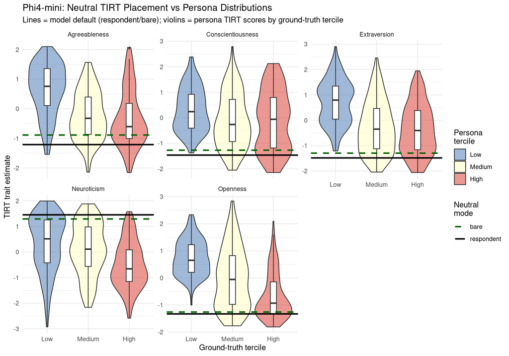

```r
neutral_plot_data <- neutral_tirt_wide %>%
  select(mode, trait, estimate)

ggplot() +
  geom_violin(data = persona_scored %>%
                mutate(tercile = factor(tercile,
                                        levels = c("Low", "Medium", "High"))),
              aes(x = tercile, y = estimate, fill = tercile),
              alpha = 0.5, scale = "width") +
  geom_boxplot(data = persona_scored %>%
                 mutate(tercile = factor(tercile,
                                          levels = c("Low", "Medium", "High"))),
               aes(x = tercile, y = estimate),
               width = 0.15, outlier.size = 0.5) +
  geom_hline(data = neutral_plot_data,
             aes(yintercept = estimate, linetype = mode, color = mode),
             linewidth = 1) +
  scale_fill_manual(values = c(Low = "#4575b4", Medium = "#ffffbf",
                                High = "#d73027"),
                    name = "Persona\ntercile") +
  scale_color_manual(values = c(respondent = "black", bare = "darkgreen"),
                     name = "Neutral\nmode") +
  scale_linetype_manual(values = c(respondent = "solid", bare = "dashed"),
                        name = "Neutral\nmode") +
  facet_wrap(~ trait, scales = "free_y", labeller = labeller(
    trait = trait_labels)) +
  labs(y = "TIRT trait estimate",
       x = "Ground-truth tercile",
       title = "Phi4-mini: Neutral TIRT Placement vs Persona Distributions",
       subtitle = "Lines = model default (respondent/bare); violins = persona TIRT scores by ground-truth tercile") +
  theme_minimal() +
  theme(legend.position = "right")
```

### Density overlay

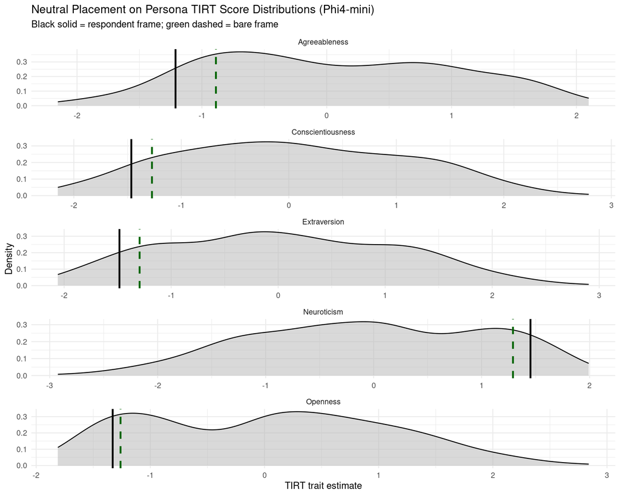

```r
ggplot(persona_tirt, aes(x = estimate)) +
  geom_density(fill = "grey70", alpha = 0.5) +
  geom_vline(data = neutral_plot_data %>% filter(mode == "respondent"),
             aes(xintercept = estimate), color = "black",
             linetype = "solid", linewidth = 1) +
  geom_vline(data = neutral_plot_data %>% filter(mode == "bare"),
             aes(xintercept = estimate), color = "darkgreen",
             linetype = "dashed", linewidth = 1) +
  facet_wrap(~ trait, scales = "free", ncol = 1, labeller = labeller(
    trait = trait_labels)) +
  labs(x = "TIRT trait estimate",
       y = "Density",
       title = "Neutral Placement on Persona TIRT Score Distributions (Phi4-mini)",
       subtitle = "Black solid = respondent frame; green dashed = bare frame") +
  theme_minimal()
```

### Neutral as percentile of persona distribution

```r
percentile_df <- neutral_plot_data %>%
  group_by(mode) %>%
  group_modify(~ {
    .x %>%
      rowwise() %>%
      mutate(
        percentile = mean(
          persona_tirt$estimate[persona_tirt$trait == trait] <= estimate
        ) * 100
      ) %>%
      ungroup()
  })

knitr::kable(percentile_df %>%
               select(mode, trait, estimate, percentile) %>%
               pivot_wider(names_from = mode,
                           values_from = c(estimate, percentile),
                           names_glue = "{mode}_{.value}"),
             digits = 2,
             caption = "Neutral placement as percentile of persona TIRT distribution")
```

Neutral placement as percentile of persona TIRT distribution

| trait | bare_estimate | respondent_estimate | bare_percentile | respondent_percentile |
| --- | --- | --- | --- | --- |
| A | -0.89 | -1.21 | 19.75 | 8.75 |
| O | -1.26 | -1.33 | 14.75 | 11.75 |
| C | -1.27 | -1.46 | 12.00 | 7.50 |
| E | -1.29 | -1.48 | 13.00 | 8.25 |
| N | 1.29 | 1.45 | 86.50 | 92.25 |

## Per-Item Comparison: Respondent vs Bare

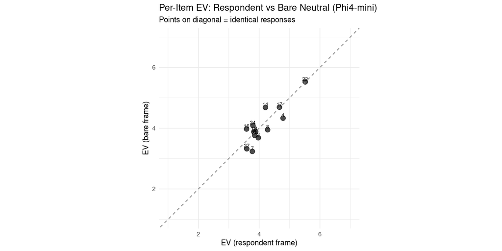

```r
resp_items <- fromJSON("phi4-mini-latest_gfc30_neutral-respondent.json",
                       flatten = TRUE)$results %>%
  as_tibble() %>%
  mutate(mode = "respondent",
         ev = as.numeric(response_ev),
         block = as.integer(block))

bare_items <- fromJSON("phi4-mini-latest_gfc30_neutral-bare.json",
                       flatten = TRUE)$results %>%
  as_tibble() %>%
  mutate(mode = "bare",
         ev = as.numeric(response_ev),
         block = as.integer(block))

item_compare <- bind_rows(resp_items, bare_items) %>%
  select(block, left_trait, right_trait, mode, ev) %>%
  pivot_wider(names_from = mode, values_from = ev)

ggplot(item_compare, aes(x = respondent, y = bare)) +
  geom_point(size = 3, alpha = 0.7) +
  geom_abline(slope = 1, intercept = 0, linetype = "dashed", color = "grey50") +
  geom_text(aes(label = block), nudge_y = 0.1, size = 2.5) +
  labs(x = "EV (respondent frame)", y = "EV (bare frame)",
       title = "Per-Item EV: Respondent vs Bare Neutral (Phi4-mini)",
       subtitle = "Points on diagonal = identical responses") +
  coord_equal(xlim = c(1, 7), ylim = c(1, 7)) +
  theme_minimal()
```

```r
cat(sprintf("Correlation between modes: r = %.3f\n",
            cor(item_compare$respondent, item_compare$bare, use = "complete.obs")))
```

```
## Correlation between modes: r = 0.859
```

```r
cat(sprintf("Mean absolute difference: %.3f\n",
            mean(abs(item_compare$respondent - item_compare$bare), na.rm = TRUE)))
```

```
## Mean absolute difference: 0.248
```

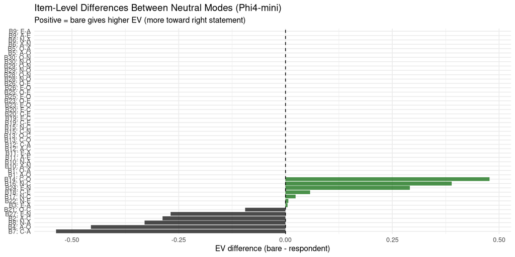

```r
item_compare %>%
  mutate(diff = bare - respondent,
         pair_label = paste0("B", block, ": ", left_trait, "-", right_trait)) %>%
  ggplot(aes(x = reorder(pair_label, diff), y = diff)) +
  geom_col(aes(fill = diff > 0), alpha = 0.7, show.legend = FALSE) +
  scale_fill_manual(values = c("TRUE" = "darkgreen", "FALSE" = "black")) +
  coord_flip() +
  geom_hline(yintercept = 0, linetype = "dashed") +
  labs(x = NULL, y = "EV difference (bare - respondent)",
       title = "Item-Level Differences Between Neutral Modes (Phi4-mini)",
       subtitle = "Positive = bare gives higher EV (more toward right statement)") +
  theme_minimal()
```

# 6. Summary

```r
cat("=== Phi4-mini GFC-30 TIRT Summary ===\n\n")
```

```
## === Phi4-mini GFC-30 TIRT Summary ===
```

```r
cat(sprintf("Personas: %d complete / %d total\n", n_complete, nrow(wide)))
```

```
## Personas: 400 complete / 400 total
```

```r
cat(sprintf("Prompts: %d\n", nrow(all_results)))
```

```
## Prompts: 12000
```

```r
cat(sprintf("Valid responses: %d (%.1f%%)\n",
            sum(!is.na(all_results$response_argmax)),
            100 * mean(!is.na(all_results$response_argmax))))
```

```
## Valid responses: 12000 (100.0%)
```

```r
cat(sprintf("Mean entropy: %.3f / %.3f (ln 7)\n",
            mean(all_results$response_entropy, na.rm = TRUE), log(7)))
```

```
## Mean entropy: 1.576 / 1.946 (ln 7)
```

```r
cat("\nGround-truth recovery (Pearson r):\n")
```

```
##
## Ground-truth recovery (Pearson r):
```

```r
for (i in seq_along(traits)) {
  cat(sprintf("  %s: TIRT=%.3f, Simple=%.3f\n",
              trait_labels[traits[i]],
              recovery$tirt_r[i], recovery$simple_r[i]))
}
```

```
##   Agreeableness: TIRT=-0.386, Simple=0.275
##   Conscientiousness: TIRT=-0.202, Simple=0.086
##   Extraversion: TIRT=-0.387, Simple=0.487
##   Neuroticism: TIRT=-0.340, Simple=0.086
##   Openness: TIRT=-0.577, Simple=0.508
```

```r
cat("\nNeutral TIRT placement:\n")
```

```
##
## Neutral TIRT placement:
```

```r
for (m in c("respondent", "bare")) {
  scores_m <- neutral_tirt_wide %>% filter(mode == m)
  cat(sprintf("  %s: %s\n", m,
              paste(scores_m %>%
                      mutate(s = sprintf("%s=%.2f (SE=%.2f)", trait, estimate, se)) %>%
                      pull(s), collapse = ", ")))
}
```

```
##   respondent: A=-1.21 (SE=0.37), O=-1.33 (SE=0.32), C=-1.46 (SE=0.31), E=-1.48 (SE=0.29), N=1.45 (SE=0.30)
##   bare: A=-0.89 (SE=0.37), O=-1.26 (SE=0.32), C=-1.27 (SE=0.30), E=-1.29 (SE=0.29), N=1.29 (SE=0.30)
```

## Key Findings

1. **Phi4-mini’s higher entropy** (mean ~1.58 nats vs Gemma3’s ~0.67) reflects a fundamentally different response process — probability is spread more evenly across the 7-point scale.
2. **TIRT with 4 chains** should show improved posterior mixing compared to Gemma3’s 2-chain run. The cross-model recovery comparison reveals whether the model’s response entropy translates to better trait identification.
3. **Neutral placement** reveals Phi4-mini’s default personality profile on the same latent scale as the synthetic personas. Differences between respondent and bare framing indicate sensitivity to role-assignment instructions.

## Next Steps

- **Multi-model joint TIRT**: Pool Gemma3 + Phi4 data for better dimensional identification.
- **Custom Stan TIRT** with LKJ prior on correlations.
- **Measurement invariance** testing across models.